# VisualizacionPRAC2

[figure not shown]

M2.859 - Visualización de datos · PRA2

2018-2 · Máster universitario en Ciencia de datos (Data science)

Estudios de Informática, Multimedia y Telecomunicación

Nombre Oscar Javier Abril Tique

# FIFA 20 Complete Player Dataset

## Descripción Dataset

Hoy en día el mundo futbol no solo se desarrolla a través de una actividad física, en diferentes ligas o torneos profesionales o aficionados, si no ha abierto otros mercados que pueden mover en algunos casos igual o mayor cantidad de recursos económicos que este y dentro de esos diferentes negocios se encuentra la industria de los videojuegos, y en este caso el conjunto de datos elegido para realizar la práctica “FIFA 20 Complete Player Dataset”, dataset que contiene los datos estadísticos de cada uno de los jugadores del videojuego “FIFA 2020”.

A Continuación, se listan los campos que componen el dataset: [link dataset Kaggle](https://www.kaggle.com/stefanoleone992/fifa-20-complete-player-dataset)

Nombre campo

1 sofifa_id

2 player_url

3 short_name

4 long_name

5 age

6 dob

7 height_cm

8 weight_kg

9 nationality

10 club

11 overall

12 potential

13 value_eur

14 wage_eur

15 player_positions

16 preferred_foot

17 international_reputation

18 weak_foot

19 skill_moves

20 work_rate

21 body_type

22 real_face

23 release_clause_eur

24 player_tags

25 team_position

26 team_jersey_number

27 loaned_from

28 joined

29 contract_valid_until

30 nation_position

31 nation_jersey_number

32 pace

33 shooting

34 passing

35 dribbling

36 defending

37 physic

38 gk_diving

39 gk_handling

40 gk_kicking

41 gk_reflexes

42 gk_speed

43 gk_positioning

44 player_traits

45 attacking_crossing

46 attacking_finishing

47 attacking_heading_accuracy

48 attacking_short_passing

49 attacking_volleys

50 skill_dribbling

51 skill_curve

52 skill_fk_accuracy

53 skill_long_passing

54 skill_ball_control

55 movement_acceleration

56 movement_sprint_speed

57 movement_agility

58 movement_reactions

59 movement_balance

60 power_shot_power

61 power_jumping

62 power_stamina

63 power_strength

64 power_long_shots

65 mentality_aggression

66 mentality_interceptions

67 mentality_positioning

68 mentality_vision

69 mentality_penalties

70 mentality_composure

71 defending_marking

72 defending_standing_tackle

73 defending_sliding_tackle

74 goalkeeping_diving

75 goalkeeping_handling

76 goalkeeping_kicking

77 goalkeeping_positioning

78 goalkeeping_reflexes

79 ls

80 st

81 rs

82 lw

83 lf

84 cf

85 rf

86 rw

87 lam

88 cam

89 ram

90 lm

91 lcm

92 cm

93 rcm

94 rm

95 lwb

96 ldm

97 cdm

98 rdm

99 rwb

100 lb

101 lcb

102 cb

103 rcb

104 rb

## Integración y selección de los datos de interés a analizar

Inicialmente se importan las librerias necesarias para la implementación de la practica:

```python
import pandas as pd
import matplotlib.pyplot as plt
#import numpy as np
import seaborn as sns
#from sklearn.pipeline import Pipeline
#from sklearn.preprocessing import StandardScaler,PolynomialFeatures
#from sklearn.linear_model import LinearRegression
#%matplotlib inline
```

Se carga dataset descargado desde kaggle [link Link Kaggle](https://www.kaggle.com/stefanoleone992/fifa-20-complete-player-dataset?select=players_20.csv)

```python
file_name='players_20.csv'
df=pd.read_csv(file_name)
```

```python
Features=['short_name','age','height_cm','weight_kg','nationality','club','overall','potential','value_eur','wage_eur','player_positions','preferred_foot','international_reputation','skill_moves','work_rate','team_position','contract_valid_until','pace','shooting','passing','dribbling','defending','attacking_short_passing','skill_dribbling','skill_fk_accuracy','skill_long_passing','skill_ball_control','power_shot_power','defending_marking','defending_standing_tackle','defending_sliding_tackle','goalkeeping_diving','goalkeeping_positioning','goalkeeping_reflexes']
df = df[Features]
```

Usamos el metodo head para apreciar los primeros 10 registros cargados en el dataframe:

```python
df.head(10)
```

|  | short_name | age | height_cm | weight_kg | nationality | club | overall | potential | value_eur | wage_eur | ... | skill_fk_accuracy | skill_long_passing | skill_ball_control | power_shot_power | defending_marking | defending_standing_tackle | defending_sliding_tackle | goalkeeping_diving | goalkeeping_positioning | goalkeeping_reflexes |
| --- | --- | --- | --- | --- | --- | --- | --- | --- | --- | --- | --- | --- | --- | --- | --- | --- | --- | --- | --- | --- | --- |
| 0 | L. Messi | 32 | 170 | 72 | Argentina | FC Barcelona | 94 | 94 | 95500000 | 565000 | ... | 94 | 92 | 96 | 86 | 33 | 37 | 26 | 6 | 14 | 8 |
| 1 | Cristiano Ronaldo | 34 | 187 | 83 | Portugal | Juventus | 93 | 93 | 58500000 | 405000 | ... | 76 | 77 | 92 | 95 | 28 | 32 | 24 | 7 | 14 | 11 |
| 2 | Neymar Jr | 27 | 175 | 68 | Brazil | Paris Saint-Germain | 92 | 92 | 105500000 | 290000 | ... | 87 | 81 | 95 | 80 | 27 | 26 | 29 | 9 | 15 | 11 |
| 3 | J. Oblak | 26 | 188 | 87 | Slovenia | Atlético Madrid | 91 | 93 | 77500000 | 125000 | ... | 14 | 40 | 30 | 59 | 27 | 12 | 18 | 87 | 90 | 89 |
| 4 | E. Hazard | 28 | 175 | 74 | Belgium | Real Madrid | 91 | 91 | 90000000 | 470000 | ... | 79 | 83 | 94 | 82 | 34 | 27 | 22 | 11 | 8 | 8 |
| 5 | K. De Bruyne | 28 | 181 | 70 | Belgium | Manchester City | 91 | 91 | 90000000 | 370000 | ... | 83 | 91 | 91 | 91 | 68 | 58 | 51 | 15 | 10 | 13 |
| 6 | M. ter Stegen | 27 | 187 | 85 | Germany | FC Barcelona | 90 | 93 | 67500000 | 250000 | ... | 12 | 63 | 30 | 66 | 25 | 13 | 10 | 88 | 88 | 90 |
| 7 | V. van Dijk | 27 | 193 | 92 | Netherlands | Liverpool | 90 | 91 | 78000000 | 200000 | ... | 70 | 81 | 76 | 81 | 91 | 92 | 85 | 13 | 11 | 11 |
| 8 | L. Modrić | 33 | 172 | 66 | Croatia | Real Madrid | 90 | 90 | 45000000 | 340000 | ... | 78 | 88 | 92 | 79 | 68 | 76 | 71 | 13 | 14 | 9 |
| 9 | M. Salah | 27 | 175 | 71 | Egypt | Liverpool | 90 | 90 | 80500000 | 240000 | ... | 69 | 75 | 89 | 80 | 38 | 43 | 41 | 14 | 11 | 14 |

10 rows × 34 columns

Se consulta el tipo de cada atributo que compone el dataframe

```python
df.dtypes
```

```
short_name                    object
age                            int64
height_cm                      int64
weight_kg                      int64
nationality                   object
club                          object
overall                        int64
potential                      int64
value_eur                      int64
wage_eur                       int64
player_positions              object
preferred_foot                object
international_reputation       int64
skill_moves                    int64
work_rate                     object
team_position                 object
contract_valid_until         float64
pace                         float64
shooting                     float64
passing                      float64
dribbling                    float64
defending                    float64
attacking_short_passing        int64
skill_dribbling                int64
skill_fk_accuracy              int64
skill_long_passing             int64
skill_ball_control             int64
power_shot_power               int64
defending_marking              int64
defending_standing_tackle      int64
defending_sliding_tackle       int64
goalkeeping_diving             int64
goalkeeping_positioning        int64
goalkeeping_reflexes           int64
dtype: object
```

Usamos el método **describe** para obtener un resumen estadístico del marco de datos.

```python
df.describe(include= "all")
```

|  | short_name | age | height_cm | weight_kg | nationality | club | overall | potential | value_eur | wage_eur | ... | skill_fk_accuracy | skill_long_passing | skill_ball_control | power_shot_power | defending_marking | defending_standing_tackle | defending_sliding_tackle | goalkeeping_diving | goalkeeping_positioning | goalkeeping_reflexes |
| --- | --- | --- | --- | --- | --- | --- | --- | --- | --- | --- | --- | --- | --- | --- | --- | --- | --- | --- | --- | --- | --- |
| count | 18278 | 18278.000000 | 18278.000000 | 18278.000000 | 18278 | 18278 | 18278.000000 | 18278.000000 | 1.827800e+04 | 18278.000000 | ... | 18278.000000 | 18278.000000 | 18278.000000 | 18278.000000 | 18278.000000 | 18278.000000 | 18278.000000 | 18278.000000 | 18278.000000 | 18278.000000 |
| unique | 17354 | NaN | NaN | NaN | 162 | 698 | NaN | NaN | NaN | NaN | ... | NaN | NaN | NaN | NaN | NaN | NaN | NaN | NaN | NaN | NaN |
| top | J. Rodríguez | NaN | NaN | NaN | England | Burnley | NaN | NaN | NaN | NaN | ... | NaN | NaN | NaN | NaN | NaN | NaN | NaN | NaN | NaN | NaN |
| freq | 11 | NaN | NaN | NaN | 1667 | 33 | NaN | NaN | NaN | NaN | ... | NaN | NaN | NaN | NaN | NaN | NaN | NaN | NaN | NaN | NaN |
| mean | NaN | 25.283291 | 181.362184 | 75.276343 | NaN | NaN | 66.244994 | 71.546887 | 2.484038e+06 | 9456.942773 | ... | 42.708885 | 52.768848 | 58.461976 | 58.181694 | 46.848889 | 47.640333 | 45.606631 | 16.572765 | 16.368038 | 16.709924 |
| std | NaN | 4.656964 | 6.756961 | 7.047744 | NaN | NaN | 6.949953 | 6.139669 | 5.585481e+06 | 21351.714095 | ... | 17.433612 | 15.246454 | 16.741878 | 13.326083 | 20.091287 | 21.585641 | 21.217734 | 17.738069 | 17.136497 | 18.038125 |
| min | NaN | 16.000000 | 156.000000 | 50.000000 | NaN | NaN | 48.000000 | 49.000000 | 0.000000e+00 | 0.000000 | ... | 4.000000 | 8.000000 | 5.000000 | 14.000000 | 1.000000 | 5.000000 | 3.000000 | 1.000000 | 1.000000 | 1.000000 |
| 25% | NaN | 22.000000 | 177.000000 | 70.000000 | NaN | NaN | 62.000000 | 67.000000 | 3.250000e+05 | 1000.000000 | ... | 31.000000 | 43.000000 | 54.000000 | 48.000000 | 29.000000 | 27.000000 | 24.000000 | 8.000000 | 8.000000 | 8.000000 |
| 50% | NaN | 25.000000 | 181.000000 | 75.000000 | NaN | NaN | 66.000000 | 71.000000 | 7.000000e+05 | 3000.000000 | ... | 41.000000 | 56.000000 | 63.000000 | 59.000000 | 52.000000 | 55.000000 | 52.000000 | 11.000000 | 11.000000 | 11.000000 |
| 75% | NaN | 29.000000 | 186.000000 | 80.000000 | NaN | NaN | 71.000000 | 75.000000 | 2.100000e+06 | 8000.000000 | ... | 56.000000 | 64.000000 | 69.000000 | 68.000000 | 64.000000 | 66.000000 | 64.000000 | 14.000000 | 14.000000 | 14.000000 |
| max | NaN | 42.000000 | 205.000000 | 110.000000 | NaN | NaN | 94.000000 | 95.000000 | 1.055000e+08 | 565000.000000 | ... | 94.000000 | 92.000000 | 96.000000 | 95.000000 | 94.000000 | 92.000000 | 90.000000 | 90.000000 | 91.000000 | 92.000000 |

11 rows × 34 columns

```python
df.shape
```

```
(18278, 34)
```

# 2.3. Limpieza de los datos

## Evaluating for Missing Data (Datos Faltantes)

Usando la función isnull en la salida evaluando el dataframe completo nos entrega un valor booleano que indica si el valor que se pasa al argumento es, de hecho, datos faltantes.

"True" significa valor perdido, mientras que "False" significa valor no perdido.

```python
missing_data = df.isnull()
missing_data.head(5)
```

|  | short_name | age | height_cm | weight_kg | nationality | club | overall | potential | value_eur | wage_eur | ... | skill_fk_accuracy | skill_long_passing | skill_ball_control | power_shot_power | defending_marking | defending_standing_tackle | defending_sliding_tackle | goalkeeping_diving | goalkeeping_positioning | goalkeeping_reflexes |
| --- | --- | --- | --- | --- | --- | --- | --- | --- | --- | --- | --- | --- | --- | --- | --- | --- | --- | --- | --- | --- | --- |
| 0 | False | False | False | False | False | False | False | False | False | False | ... | False | False | False | False | False | False | False | False | False | False |
| 1 | False | False | False | False | False | False | False | False | False | False | ... | False | False | False | False | False | False | False | False | False | False |
| 2 | False | False | False | False | False | False | False | False | False | False | ... | False | False | False | False | False | False | False | False | False | False |
| 3 | False | False | False | False | False | False | False | False | False | False | ... | False | False | False | False | False | False | False | False | False | False |
| 4 | False | False | False | False | False | False | False | False | False | False | ... | False | False | False | False | False | False | False | False | False | False |

5 rows × 34 columns

```python
df.isnull().sum()
```

```
short_name                      0
age                             0
height_cm                       0
weight_kg                       0
nationality                     0
club                            0
overall                         0
potential                       0
value_eur                       0
wage_eur                        0
player_positions                0
preferred_foot                  0
international_reputation        0
skill_moves                     0
work_rate                       0
team_position                 240
contract_valid_until          240
pace                         2036
shooting                     2036
passing                      2036
dribbling                    2036
defending                    2036
attacking_short_passing         0
skill_dribbling                 0
skill_fk_accuracy               0
skill_long_passing              0
skill_ball_control              0
power_shot_power                0
defending_marking               0
defending_standing_tackle       0
defending_sliding_tackle        0
goalkeeping_diving              0
goalkeeping_positioning         0
goalkeeping_reflexes            0
dtype: int64
```

Usando un bucle podemos calcular rápidamente el número de valores faltantes en cada columna. Como se mencionó anteriormente, "True" representa un valor faltante, "False" significa que el valor está presente en el conjunto de datos. En el cuerpo del bucle for, el método ".value_counts ()" cuenta el número de valores "True".

```python
for column in missing_data.columns.values.tolist():
    print(column)
    print (missing_data[column].value_counts())
    print("")
```

```
short_name
False    18278
Name: short_name, dtype: int64

age
False    18278
Name: age, dtype: int64

height_cm
False    18278
Name: height_cm, dtype: int64

weight_kg
False    18278
Name: weight_kg, dtype: int64

nationality
False    18278
Name: nationality, dtype: int64

club
False    18278
Name: club, dtype: int64

overall
False    18278
Name: overall, dtype: int64

potential
False    18278
Name: potential, dtype: int64

value_eur
False    18278
Name: value_eur, dtype: int64

wage_eur
False    18278
Name: wage_eur, dtype: int64

```

[output cut: 87 more lines]

```
defending_sliding_tackle
False    18278
Name: defending_sliding_tackle, dtype: int64

goalkeeping_diving
False    18278
Name: goalkeeping_diving, dtype: int64

goalkeeping_positioning
False    18278
Name: goalkeeping_positioning, dtype: int64

goalkeeping_reflexes
False    18278
Name: goalkeeping_reflexes, dtype: int64
```

después de tener una idea sobre los tipos en nuestro conjunto de datos, necesitamos verificar los valores faltantes. una forma es usar un mapa de calor junto con isna ()

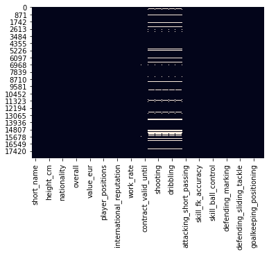

```python
sns.heatmap(df.isna(), cbar=False)
```

```python
((df.shape[0]-df.isna().sum())/df.shape[0])*100
```

```
short_name                   100.000000
age                          100.000000
height_cm                    100.000000
weight_kg                    100.000000
nationality                  100.000000
club                         100.000000
overall                      100.000000
potential                    100.000000
value_eur                    100.000000
wage_eur                     100.000000
player_positions             100.000000
preferred_foot               100.000000
international_reputation     100.000000
skill_moves                  100.000000
work_rate                    100.000000
team_position                 98.686946
contract_valid_until          98.686946
pace                          88.860926
shooting                      88.860926
passing                       88.860926
dribbling                     88.860926
defending                     88.860926
attacking_short_passing      100.000000
skill_dribbling              100.000000
skill_fk_accuracy            100.000000
skill_long_passing           100.000000
skill_ball_control           100.000000
power_shot_power             100.000000
defending_marking            100.000000
defending_standing_tackle    100.000000
defending_sliding_tackle     100.000000
goalkeeping_diving           100.000000
goalkeeping_positioning      100.000000
goalkeeping_reflexes         100.000000
dtype: float64
```

## Identificación y tratamiento de valores extremos

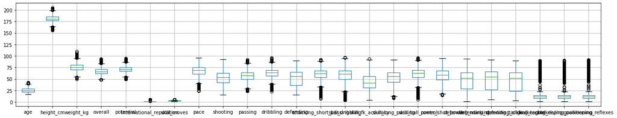

```python
num_col = ['age','height_cm','weight_kg','overall','potential','international_reputation','skill_moves','pace','shooting','passing','dribbling','defending','attacking_short_passing','skill_dribbling','skill_fk_accuracy','skill_long_passing','skill_ball_control','power_shot_power','defending_marking','defending_standing_tackle','defending_sliding_tackle','goalkeeping_diving','goalkeeping_positioning','goalkeeping_reflexes']

df[num_col].boxplot(return_type='axes',figsize=(22,4));
```

# Análisis de los datos.

```python
cat_col = ['short_name','nationality','club','player_positions','preferred_foot','work_rate','team_position']
num_col = ['age','height_cm','weight_kg','overall','potential','value_eur','wage_eur','international_reputation','skill_moves','contract_valid_until','pace','shooting','passing','dribbling','defending','attacking_short_passing','skill_dribbling','skill_fk_accuracy','skill_long_passing','skill_ball_control','power_shot_power','defending_marking','defending_standing_tackle','defending_sliding_tackle','goalkeeping_diving','goalkeeping_positioning','goalkeeping_reflexes']
```

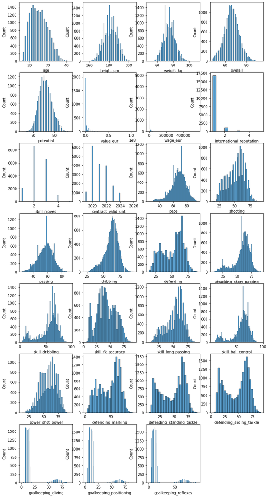

```python
#Numerical Data
plt.figure(figsize=(12, 42))
count = 1
for cols in num_col:
    plt.subplot(12, 4, count)
    sns.histplot(df.loc[df[cols].notna(), cols])
    count+=1
```

Análisis de datos Numericos

Análisis de Datos Categoricos

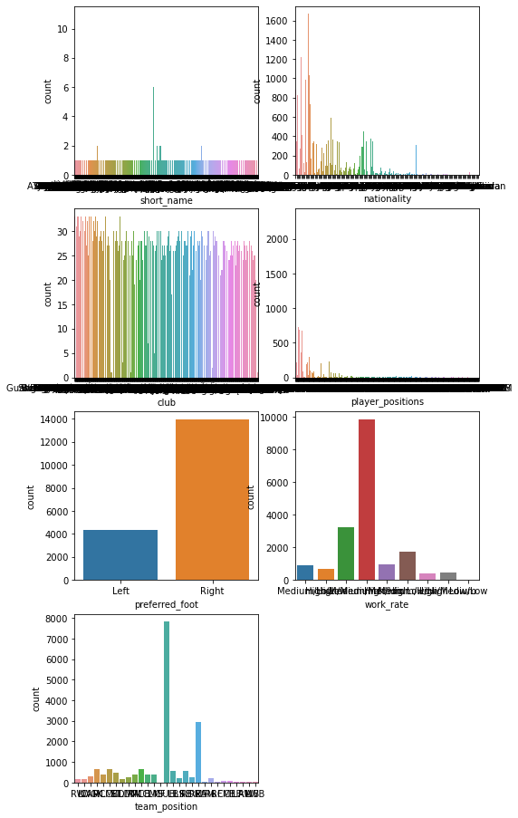

```python
#Categorical Data
plt.figure(figsize=(8, 24))
count = 1
for cols in cat_col:

    plt.subplot(6, 2, count)
    sns.countplot(x=cols, data=df)
    count+=1
```

### El resultado del proceso arrojo que las variables age, value_eur y wage_eur deberán ser convertidas en variables categóricas para mejorar la visualización.

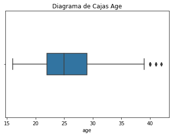

```python
sns.boxplot(x=df.age, width= 0.2, orient="Vertical").set(title='Diagrama de Cajas Age');
```

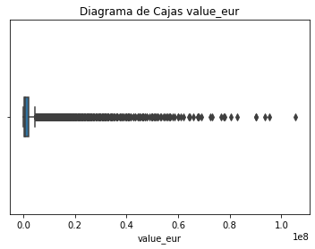

```python
sns.boxplot(x=df.value_eur , width= 0.2, orient="Vertical").set(title='Diagrama de Cajas value_eur');
```

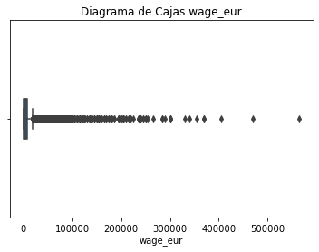

```python
sns.boxplot(x=df.wage_eur , width= 0.2, orient="Vertical").set(title='Diagrama de Cajas wage_eur');
```

### age

```python
# se crea el rango de edad
bins = [0,9,15,19,25,29,35,39,49]
names =["0-9","10-15","16-19","20-25","26-29","30-35","36-39","40-49"]
# se crea la nueva columna con el rango de edad
df['RangoEdad']=pd.cut(df['age'],bins,labels=names)
```

```python
df.head(20)
```

|  | short_name | age | height_cm | weight_kg | nationality | club | overall | potential | value_eur | wage_eur | ... | skill_long_passing | skill_ball_control | power_shot_power | defending_marking | defending_standing_tackle | defending_sliding_tackle | goalkeeping_diving | goalkeeping_positioning | goalkeeping_reflexes | RangoEdad |
| --- | --- | --- | --- | --- | --- | --- | --- | --- | --- | --- | --- | --- | --- | --- | --- | --- | --- | --- | --- | --- | --- |
| 0 | L. Messi | 32 | 170 | 72 | Argentina | FC Barcelona | 94 | 94 | 95500000 | 565000 | ... | 92 | 96 | 86 | 33 | 37 | 26 | 6 | 14 | 8 | 30-35 |
| 1 | Cristiano Ronaldo | 34 | 187 | 83 | Portugal | Juventus | 93 | 93 | 58500000 | 405000 | ... | 77 | 92 | 95 | 28 | 32 | 24 | 7 | 14 | 11 | 30-35 |
| 2 | Neymar Jr | 27 | 175 | 68 | Brazil | Paris Saint-Germain | 92 | 92 | 105500000 | 290000 | ... | 81 | 95 | 80 | 27 | 26 | 29 | 9 | 15 | 11 | 26-29 |
| 3 | J. Oblak | 26 | 188 | 87 | Slovenia | Atlético Madrid | 91 | 93 | 77500000 | 125000 | ... | 40 | 30 | 59 | 27 | 12 | 18 | 87 | 90 | 89 | 26-29 |
| 4 | E. Hazard | 28 | 175 | 74 | Belgium | Real Madrid | 91 | 91 | 90000000 | 470000 | ... | 83 | 94 | 82 | 34 | 27 | 22 | 11 | 8 | 8 | 26-29 |
| 5 | K. De Bruyne | 28 | 181 | 70 | Belgium | Manchester City | 91 | 91 | 90000000 | 370000 | ... | 91 | 91 | 91 | 68 | 58 | 51 | 15 | 10 | 13 | 26-29 |
| 6 | M. ter Stegen | 27 | 187 | 85 | Germany | FC Barcelona | 90 | 93 | 67500000 | 250000 | ... | 63 | 30 | 66 | 25 | 13 | 10 | 88 | 88 | 90 | 26-29 |
| 7 | V. van Dijk | 27 | 193 | 92 | Netherlands | Liverpool | 90 | 91 | 78000000 | 200000 | ... | 81 | 76 | 81 | 91 | 92 | 85 | 13 | 11 | 11 | 26-29 |
| 8 | L. Modrić | 33 | 172 | 66 | Croatia | Real Madrid | 90 | 90 | 45000000 | 340000 | ... | 88 | 92 | 79 | 68 | 76 | 71 | 13 | 14 | 9 | 30-35 |
| 9 | M. Salah | 27 | 175 | 71 | Egypt | Liverpool | 90 | 90 | 80500000 | 240000 | ... | 75 | 89 | 80 | 38 | 43 | 41 | 14 | 11 | 14 | 26-29 |
| 10 | K. Mbappé | 20 | 178 | 73 | France | Paris Saint-Germain | 89 | 95 | 93500000 | 155000 | ... | 70 | 90 | 83 | 34 | 34 | 32 | 13 | 11 | 6 | 20-25 |
| 11 | K. Koulibaly | 28 | 187 | 89 | Senegal | Napoli | 89 | 91 | 67500000 | 150000 | ... | 63 | 71 | 55 | 91 | 90 | 87 | 7 | 13 | 5 | 26-29 |
| 12 | H. Kane | 25 | 188 | 89 | England | Tottenham Hotspur | 89 | 91 | 83000000 | 220000 | ... | 83 | 84 | 90 | 56 | 36 | 38 | 8 | 14 | 11 | 20-25 |
| 13 | Alisson | 26 | 191 | 91 | Brazil | Liverpool | 89 | 91 | 58000000 | 155000 | ... | 44 | 30 | 64 | 15 | 19 | 16 | 85 | 90 | 89 | 26-29 |
| 14 | De Gea | 28 | 192 | 82 | Spain | Manchester United | 89 | 90 | 56000000 | 205000 | ... | 47 | 38 | 61 | 25 | 21 | 13 | 90 | 85 | 92 | 26-29 |
| 15 | N. Kanté | 28 | 168 | 72 | France | Chelsea | 89 | 90 | 66000000 | 235000 | ... | 81 | 80 | 71 | 90 | 91 | 85 | 15 | 7 | 10 | 26-29 |
| 16 | G. Chiellini | 34 | 187 | 85 | Italy | Juventus | 89 | 89 | 24500000 | 215000 | ... | 65 | 61 | 78 | 94 | 91 | 89 | 3 | 4 | 3 | 30-35 |
| 17 | S. Agüero | 31 | 173 | 70 | Argentina | Manchester City | 89 | 89 | 60000000 | 300000 | ... | 64 | 89 | 89 | 30 | 29 | 24 | 13 | 11 | 14 | 30-35 |
| 18 | Sergio Ramos | 33 | 184 | 82 | Spain | Real Madrid | 89 | 89 | 31500000 | 300000 | ... | 83 | 83 | 79 | 85 | 87 | 90 | 11 | 7 | 11 | 30-35 |
| 19 | L. Suárez | 32 | 182 | 86 | Uruguay | FC Barcelona | 89 | 89 | 53000000 | 355000 | ... | 72 | 84 | 88 | 57 | 45 | 38 | 27 | 33 | 37 | 30-35 |

20 rows × 35 columns

### value_eur

```python
# se crea el rango de value_eur
bins = [0,100000,500000,1000000,5000000,10000000,50000000,100000000,1000000000]
names =["€0-100K","€100-500K","€500k-1M","€1-5M","€5-10M","€10-50M","€50-100M","€>100M"]

# se crea la nueva columna con el rango de edad
df['RangoValue_eur']=pd.cut(df['value_eur'],bins,labels=names)
df.head(200)
```

|  | short_name | age | height_cm | weight_kg | nationality | club | overall | potential | value_eur | wage_eur | ... | skill_ball_control | power_shot_power | defending_marking | defending_standing_tackle | defending_sliding_tackle | goalkeeping_diving | goalkeeping_positioning | goalkeeping_reflexes | RangoEdad | RangoValue_eur |
| --- | --- | --- | --- | --- | --- | --- | --- | --- | --- | --- | --- | --- | --- | --- | --- | --- | --- | --- | --- | --- | --- |
| 0 | L. Messi | 32 | 170 | 72 | Argentina | FC Barcelona | 94 | 94 | 95500000 | 565000 | ... | 96 | 86 | 33 | 37 | 26 | 6 | 14 | 8 | 30-35 | €50-100M |
| 1 | Cristiano Ronaldo | 34 | 187 | 83 | Portugal | Juventus | 93 | 93 | 58500000 | 405000 | ... | 92 | 95 | 28 | 32 | 24 | 7 | 14 | 11 | 30-35 | €50-100M |
| 2 | Neymar Jr | 27 | 175 | 68 | Brazil | Paris Saint-Germain | 92 | 92 | 105500000 | 290000 | ... | 95 | 80 | 27 | 26 | 29 | 9 | 15 | 11 | 26-29 | €>100M |
| 3 | J. Oblak | 26 | 188 | 87 | Slovenia | Atlético Madrid | 91 | 93 | 77500000 | 125000 | ... | 30 | 59 | 27 | 12 | 18 | 87 | 90 | 89 | 26-29 | €50-100M |
| 4 | E. Hazard | 28 | 175 | 74 | Belgium | Real Madrid | 91 | 91 | 90000000 | 470000 | ... | 94 | 82 | 34 | 27 | 22 | 11 | 8 | 8 | 26-29 | €50-100M |
| ... | ... | ... | ... | ... | ... | ... | ... | ... | ... | ... | ... | ... | ... | ... | ... | ... | ... | ... | ... | ... | ... |
| 195 | Pablo Sarabia | 27 | 174 | 70 | Spain | Paris Saint-Germain | 83 | 84 | 29500000 | 105000 | ... | 85 | 76 | 60 | 54 | 49 | 16 | 6 | 14 | 26-29 | €10-50M |
| 196 | J. Cillessen | 30 | 185 | 83 | Netherlands | Valencia CF | 83 | 84 | 20000000 | 39000 | ... | 32 | 59 | 18 | 12 | 11 | 82 | 81 | 83 | 30-35 | €10-50M |
| 197 | Lucas Moura | 26 | 174 | 70 | Brazil | Tottenham Hotspur | 83 | 84 | 31000000 | 130000 | ... | 83 | 79 | 31 | 43 | 44 | 9 | 7 | 14 | 26-29 | €10-50M |
| 198 | F. Thauvin | 26 | 179 | 70 | France | Olympique de Marseille | 83 | 84 | 30500000 | 60000 | ... | 84 | 83 | 46 | 29 | 31 | 8 | 10 | 9 | 26-29 | €10-50M |
| 199 | Jorginho | 27 | 180 | 67 | Italy | Chelsea | 83 | 84 | 29000000 | 140000 | ... | 85 | 71 | 62 | 77 | 70 | 14 | 14 | 8 | 26-29 | €10-50M |

200 rows × 36 columns

### wage_eur

```python
# se crea el rango de wage_eur
bins = [0,10000,50000,100000,500000,1000000]
names =["€0-10K","€10-50K","€50k-100K","€100-500K","€>500K"]

# se crea la nueva columna con el rango de edad
df['RangeWage_eur']=pd.cut(df['wage_eur'],bins,labels=names)
df.head(200)
```

|  | short_name | age | height_cm | weight_kg | nationality | club | overall | potential | value_eur | wage_eur | ... | power_shot_power | defending_marking | defending_standing_tackle | defending_sliding_tackle | goalkeeping_diving | goalkeeping_positioning | goalkeeping_reflexes | RangoEdad | RangoValue_eur | RangeWage_eur |
| --- | --- | --- | --- | --- | --- | --- | --- | --- | --- | --- | --- | --- | --- | --- | --- | --- | --- | --- | --- | --- | --- |
| 0 | L. Messi | 32 | 170 | 72 | Argentina | FC Barcelona | 94 | 94 | 95500000 | 565000 | ... | 86 | 33 | 37 | 26 | 6 | 14 | 8 | 30-35 | €50-100M | €>500K |
| 1 | Cristiano Ronaldo | 34 | 187 | 83 | Portugal | Juventus | 93 | 93 | 58500000 | 405000 | ... | 95 | 28 | 32 | 24 | 7 | 14 | 11 | 30-35 | €50-100M | €100-500K |
| 2 | Neymar Jr | 27 | 175 | 68 | Brazil | Paris Saint-Germain | 92 | 92 | 105500000 | 290000 | ... | 80 | 27 | 26 | 29 | 9 | 15 | 11 | 26-29 | €>100M | €100-500K |
| 3 | J. Oblak | 26 | 188 | 87 | Slovenia | Atlético Madrid | 91 | 93 | 77500000 | 125000 | ... | 59 | 27 | 12 | 18 | 87 | 90 | 89 | 26-29 | €50-100M | €100-500K |
| 4 | E. Hazard | 28 | 175 | 74 | Belgium | Real Madrid | 91 | 91 | 90000000 | 470000 | ... | 82 | 34 | 27 | 22 | 11 | 8 | 8 | 26-29 | €50-100M | €100-500K |
| ... | ... | ... | ... | ... | ... | ... | ... | ... | ... | ... | ... | ... | ... | ... | ... | ... | ... | ... | ... | ... | ... |
| 195 | Pablo Sarabia | 27 | 174 | 70 | Spain | Paris Saint-Germain | 83 | 84 | 29500000 | 105000 | ... | 76 | 60 | 54 | 49 | 16 | 6 | 14 | 26-29 | €10-50M | €100-500K |
| 196 | J. Cillessen | 30 | 185 | 83 | Netherlands | Valencia CF | 83 | 84 | 20000000 | 39000 | ... | 59 | 18 | 12 | 11 | 82 | 81 | 83 | 30-35 | €10-50M | €10-50K |
| 197 | Lucas Moura | 26 | 174 | 70 | Brazil | Tottenham Hotspur | 83 | 84 | 31000000 | 130000 | ... | 79 | 31 | 43 | 44 | 9 | 7 | 14 | 26-29 | €10-50M | €100-500K |
| 198 | F. Thauvin | 26 | 179 | 70 | France | Olympique de Marseille | 83 | 84 | 30500000 | 60000 | ... | 83 | 46 | 29 | 31 | 8 | 10 | 9 | 26-29 | €10-50M | €50k-100K |
| 199 | Jorginho | 27 | 180 | 67 | Italy | Chelsea | 83 | 84 | 29000000 | 140000 | ... | 71 | 62 | 77 | 70 | 14 | 14 | 8 | 26-29 | €10-50M | €100-500K |

200 rows × 37 columns

```python
df.head(2000)
```

|  | short_name | age | height_cm | weight_kg | nationality | club | overall | potential | value_eur | wage_eur | ... | power_shot_power | defending_marking | defending_standing_tackle | defending_sliding_tackle | goalkeeping_diving | goalkeeping_positioning | goalkeeping_reflexes | RangoEdad | RangoValue_eur | RangeWage_eur |
| --- | --- | --- | --- | --- | --- | --- | --- | --- | --- | --- | --- | --- | --- | --- | --- | --- | --- | --- | --- | --- | --- |
| 0 | L. Messi | 32 | 170 | 72 | Argentina | FC Barcelona | 94 | 94 | 95500000 | 565000 | ... | 86 | 33 | 37 | 26 | 6 | 14 | 8 | 30-35 | €50-100M | €>500K |
| 1 | Cristiano Ronaldo | 34 | 187 | 83 | Portugal | Juventus | 93 | 93 | 58500000 | 405000 | ... | 95 | 28 | 32 | 24 | 7 | 14 | 11 | 30-35 | €50-100M | €100-500K |
| 2 | Neymar Jr | 27 | 175 | 68 | Brazil | Paris Saint-Germain | 92 | 92 | 105500000 | 290000 | ... | 80 | 27 | 26 | 29 | 9 | 15 | 11 | 26-29 | €>100M | €100-500K |
| 3 | J. Oblak | 26 | 188 | 87 | Slovenia | Atlético Madrid | 91 | 93 | 77500000 | 125000 | ... | 59 | 27 | 12 | 18 | 87 | 90 | 89 | 26-29 | €50-100M | €100-500K |
| 4 | E. Hazard | 28 | 175 | 74 | Belgium | Real Madrid | 91 | 91 | 90000000 | 470000 | ... | 82 | 34 | 27 | 22 | 11 | 8 | 8 | 26-29 | €50-100M | €100-500K |
| ... | ... | ... | ... | ... | ... | ... | ... | ... | ... | ... | ... | ... | ... | ... | ... | ... | ... | ... | ... | ... | ... |
| 1995 | W. Bony | 30 | 182 | 88 | Ivory Coast | Côte d'Ivoire | 75 | 75 | 0 | 0 | ... | 83 | 24 | 42 | 28 | 10 | 7 | 11 | 30-35 | NaN | NaN |
| 1996 | Y. Salibur | 28 | 177 | 76 | France | En Avant de Guingamp | 75 | 75 | 6500000 | 10000 | ... | 78 | 37 | 33 | 35 | 12 | 10 | 7 | 26-29 | €5-10M | €0-10K |
| 1997 | D. Le Tallec | 29 | 187 | 80 | France | Montpellier HSC | 75 | 75 | 5500000 | 28000 | ... | 67 | 76 | 76 | 73 | 10 | 10 | 10 | 26-29 | €5-10M | €10-50K |
| 1998 | M. Gulde | 28 | 184 | 80 | Germany | SC Freiburg | 75 | 75 | 6000000 | 22000 | ... | 50 | 77 | 80 | 76 | 10 | 16 | 15 | 26-29 | €5-10M | €10-50K |
| 1999 | T. Arslan | 28 | 180 | 77 | Germany | Fenerbahçe SK | 75 | 75 | 6000000 | 51000 | ... | 82 | 68 | 74 | 69 | 6 | 6 | 6 | 26-29 | €5-10M | €50k-100K |

2000 rows × 37 columns

```python
# se expoarta el 2 dataset
df.to_csv (r'players_FIFA20.csv', index = False, header = True)
```

Para consultar el dataset en Github entrar al siguiente link: [link dataset Github](https://github.com/oabrilt/VisualizacionPRAC2/blob/gh-pages/players_FIFA20.csv)